# PracticalMachineLearningProject

Pratyush Mohanty

19 December 2018

This project is created as a part of the assignment for the “Practical Machine Learning” class in Coursera from John-Hopkins University.

## Synopsis

Using devices such as *Jawbone Up, Nike FuelBand, and Fitbit* it is now possible to collect a large amount of data about personal activity relatively inexpensively. These type of devices are part of the *quantified self movement* - a group of enthusiasts who take measurements about themselves regularly to improve their health, to find patterns in their behavior, or because they are tech geeks.

One thing that people regularly do is quantify how much of a particular activity they do, but they rarely quantify *how well they do it*. The goal of this project is to use data from accelerometers on the belt, forearm, arm, and dumbell of 6 participants and predict the manner in which they did the exercise. This is the *“classe”* variable in the training set.

### Data Source

The data for this project come from this source: http://groupware.les.inf.puc-rio.br/har.

The training data for this project are available here:

https://d396qusza40orc.cloudfront.net/predmachlearn/pml-training.csv

The test data are available here:

https://d396qusza40orc.cloudfront.net/predmachlearn/pml-testing.csv

```r
library(caret)
library(rattle)
library(gbm)
library(ggplot2)
```

## Data Processing - Getting and cleaning data

### Training Set

```r
## Download
if(!file.exists("pml-training.csv"))
{
        url_training <- "https://d396qusza40orc.cloudfront.net/predmachlearn/pml-training.csv"
        download.file(url_training, "pml-training.csv")
        downloadDate <- date()
        paste("Data downloaded from \n", url_training, "\n on: ", downloadDate, sep = "")
}
## read the file, treat blanks as NAs
training <- read.csv("pml-training.csv", header=TRUE, na.strings=c(""," ","NA"))

print(paste("The training dataset has ", nrow(training), " rows and ",
            ncol(training), " columns.", sep=""))
```

```
## [1] "The training dataset has 19622 rows and 160 columns."
```

### Testing Set

```r
## Download
if(!file.exists("pml-testing.csv"))
{
        url_testing <- "https://d396qusza40orc.cloudfront.net/predmachlearn/pml-testing.csv"
        download.file(url_testing, "pml-testing.csv")
        downloadDate <- date()
        paste("Data downloaded from \n", url_testing, "\n on: ", downloadDate, sep = "")
}
## load the file, treat blanks as NAs
testing <- read.csv("pml-testing.csv", header=TRUE, na.strings=c(""," ","NA"))

print(paste("The test dataset has ", nrow(testing), " rows and ",
            ncol(testing), " columns.", sep=""))
```

```
## [1] "The test dataset has 20 rows and 160 columns."
```

```r
str(training)
```

```
## 'data.frame':    19622 obs. of  160 variables:
##  $ X                       : int  1 2 3 4 5 6 7 8 9 10 ...
##  $ user_name               : Factor w/ 6 levels "adelmo","carlitos",..: 2 2 2 2 2 2 2 2 2 2 ...
##  $ raw_timestamp_part_1    : int  1323084231 1323084231 1323084231 1323084232 1323084232 1323084232 1323084232 1323084232 1323084232 1323084232 ...
##  $ raw_timestamp_part_2    : int  788290 808298 820366 120339 196328 304277 368296 440390 484323 484434 ...
##  $ cvtd_timestamp          : Factor w/ 20 levels "02/12/2011 13:32",..: 9 9 9 9 9 9 9 9 9 9 ...
##  $ new_window              : Factor w/ 2 levels "no","yes": 1 1 1 1 1 1 1 1 1 1 ...
##  $ num_window              : int  11 11 11 12 12 12 12 12 12 12 ...
##  $ roll_belt               : num  1.41 1.41 1.42 1.48 1.48 1.45 1.42 1.42 1.43 1.45 ...
##  $ pitch_belt              : num  8.07 8.07 8.07 8.05 8.07 8.06 8.09 8.13 8.16 8.17 ...
##  $ yaw_belt                : num  -94.4 -94.4 -94.4 -94.4 -94.4 -94.4 -94.4 -94.4 -94.4 -94.4 ...
##  $ total_accel_belt        : int  3 3 3 3 3 3 3 3 3 3 ...
##  $ kurtosis_roll_belt      : Factor w/ 396 levels "-0.016850","-0.021024",..: NA NA NA NA NA NA NA NA NA NA ...
##  $ kurtosis_picth_belt     : Factor w/ 316 levels "-0.021887","-0.060755",..: NA NA NA NA NA NA NA NA NA NA ...
##  $ kurtosis_yaw_belt       : Factor w/ 1 level "#DIV/0!": NA NA NA NA NA NA NA NA NA NA ...
```

[output cut: 86 more lines]

#### Are there any missing values?

```r
print_na_vals <- function(df, name) {
        numOfvaluesMissing <- nrow(is.na(df))
        percentageMissing <- mean(is.na(df))*100

        paste("There are", format(numOfvaluesMissing, big.mark=","), "(=",
              format(round(percentageMissing, 2), big.mark=","),
              "%) missing values in the", name,"set.", sep = " ")
}

print_na_vals(training, "training")
```

[output not shown]

```r
print_na_vals(testing, "testing")
```

```
## [1] "There are 20 (= 62.5 %) missing values in the testing set."
```

```r
nacols <- function(df) {
    colnames(df)[unlist(lapply(df, function(x) any(is.na(x))))]
}

na_colnames <- nacols(training)

print(paste("There are ", length(na_colnames), " NA columns.", sep=""))
```

```
## [1] "There are 100 NA columns."
```

There are a lot of NA columns, so we’ll drop them.

```r
training <- training[, !names(training) %in% na_colnames]
testing <- testing[, !names(testing)  %in% na_colnames]

print_na_vals(training, "training")
```

[output not shown]

```r
print_na_vals(testing, "testing")
```

```
## [1] "There are 20 (= 0 %) missing values in the testing set."
```

```r
print(paste("The training dataset has ", nrow(training), " rows and ",
            ncol(training), " columns.", sep=""))
```

```
## [1] "The training dataset has 19622 rows and 60 columns."
```

```r
print(paste("The test dataset has ", nrow(testing), " rows and ",
            ncol(testing), " columns.", sep=""))
```

```
## [1] "The test dataset has 20 rows and 60 columns."
```

## Analysis

We still have a lot of columns,i.e. predictors.

The first column in the datasets is just the rowid. So we can just drop that column as a feature.

```r
training <- training[, -1]
testing <- testing[, -1]
```

By looking at the data, we can also remove some of the other columns like - user_name, raw_timestamp_part_1, cvtd_timestamp, num_window

```r
columns_to_discard <- c("user_name", "raw_timestamp_part_1","raw_timestamp_part_2","cvtd_timestamp","num_window" )
training <- training[, !colnames(training) %in% columns_to_discard]
testing <- testing[, !colnames(testing) %in% columns_to_discard]
```

Remove columns with near zero variance.

```r
nzv <- nearZeroVar(training)
training <- training[, -nzv]
testing  <- testing[, -nzv]

print(dim(training))
```

```
## [1] 19622    53
```

```r
print(dim(testing))
```

```
## [1] 20 53
```

Find variables which are highly correlated.

```r
#get correlation except the target variable, which is the last column
data_to_check <- training[, -ncol(training)]
#get only numeric data
numeric_data <- data_to_check[, sapply(data_to_check, is.numeric)]
M <- abs(cor(numeric_data))
diag(M) <- 0
which(M > 0.8, arr.ind = TRUE)
```

```
##                  row col
## yaw_belt           3   1
## total_accel_belt   4   1
## accel_belt_y       9   1
## accel_belt_z      10   1
## accel_belt_x       8   2
## magnet_belt_x     11   2
## roll_belt          1   3
## roll_belt          1   4
## accel_belt_y       9   4
## accel_belt_z      10   4
## pitch_belt         2   8
## magnet_belt_x     11   8
## roll_belt          1   9
## total_accel_belt   4   9
## accel_belt_z      10   9
## roll_belt          1  10
## total_accel_belt   4  10
## accel_belt_y       9  10
## pitch_belt         2  11
## accel_belt_x       8  11
## gyros_arm_y       19  18
## gyros_arm_x       18  19
## magnet_arm_x      24  21
## accel_arm_x       21  24
## magnet_arm_z      26  25
## magnet_arm_y      25  26
## accel_dumbbell_x  34  28
## accel_dumbbell_z  36  29
## gyros_dumbbell_z  33  31
## gyros_forearm_z   46  31
## gyros_dumbbell_x  31  33
## gyros_forearm_z   46  33
## pitch_dumbbell    28  34
## yaw_dumbbell      29  36
## gyros_forearm_z   46  45
## gyros_dumbbell_x  31  46
## gyros_dumbbell_z  33  46
## gyros_forearm_y   45  46
```

There are quite a few variables which seem highly correlated. Thus, it might be a good idea to use PCA for preprocessing the data.

**Here’s a list of the final list of features.**

```r
names(training)
```

```
##  [1] "roll_belt"            "pitch_belt"           "yaw_belt"
##  [4] "total_accel_belt"     "gyros_belt_x"         "gyros_belt_y"
##  [7] "gyros_belt_z"         "accel_belt_x"         "accel_belt_y"
## [10] "accel_belt_z"         "magnet_belt_x"        "magnet_belt_y"
## [13] "magnet_belt_z"        "roll_arm"             "pitch_arm"
## [16] "yaw_arm"              "total_accel_arm"      "gyros_arm_x"
## [19] "gyros_arm_y"          "gyros_arm_z"          "accel_arm_x"
## [22] "accel_arm_y"          "accel_arm_z"          "magnet_arm_x"
## [25] "magnet_arm_y"         "magnet_arm_z"         "roll_dumbbell"
## [28] "pitch_dumbbell"       "yaw_dumbbell"         "total_accel_dumbbell"
## [31] "gyros_dumbbell_x"     "gyros_dumbbell_y"     "gyros_dumbbell_z"
## [34] "accel_dumbbell_x"     "accel_dumbbell_y"     "accel_dumbbell_z"
## [37] "magnet_dumbbell_x"    "magnet_dumbbell_y"    "magnet_dumbbell_z"
## [40] "roll_forearm"         "pitch_forearm"        "yaw_forearm"
## [43] "total_accel_forearm"  "gyros_forearm_x"      "gyros_forearm_y"
## [46] "gyros_forearm_z"      "accel_forearm_x"      "accel_forearm_y"
## [49] "accel_forearm_z"      "magnet_forearm_x"     "magnet_forearm_y"
## [52] "magnet_forearm_z"     "classe"
```

## Prepare the data

Now that we have clean data, lets try a few models to predict the ‘Classe’ variable. The test dataset doesn’t have the output variable ‘Classe’.

We’ll split the training set to a train/validate set further.

#### Set Seed

```r
set.seed(1001)
```

### Split data to Train/Validate/Test

```r
inTrain = createDataPartition(training$classe, p = 3/4, list = FALSE)
train_model = training[ inTrain,]
validate_model = training[-inTrain,]

dim(train_model)
```

```
## [1] 14718    53
```

```r
dim(validate_model)
```

```
## [1] 4904   53
```

```r
dim(testing)
```

```
## [1] 20 53
```

## Model Building

This is a classification problem and the output variable is a factor variable. We can try some of the following machine learning models -

- Classification Trees
- Random Forest
- Gradient Boosting

### Classification Tree

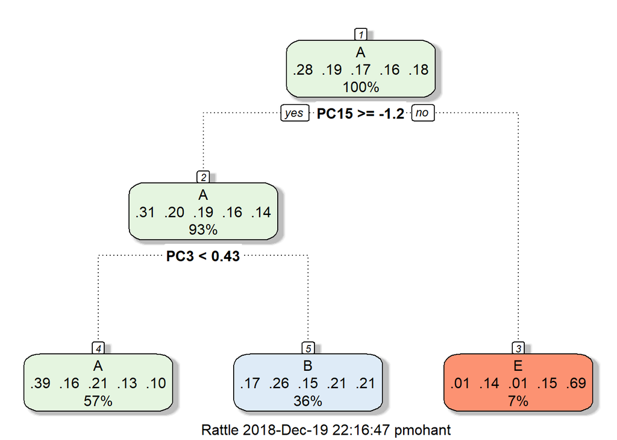

```r
set.seed(1004)
model_ctree <- train(classe ~ .,
                     data=train_model,
                     preProcess="pca",
                     method="rpart")

fancyRpartPlot(model_ctree$finalModel)
```

#### Evaluate the model

```r
predict_ctree <- predict(model_ctree, validate_model)
cm_ctree <- confusionMatrix(predict_ctree, validate_model$classe)
print(cm_ctree)
```

```
## Confusion Matrix and Statistics
##
##           Reference
## Prediction    A    B    C    D    E
##          A 1086  454  545  364  294
##          B  306  457  304  403  357
##          C    0    0    0    0    0
##          D    0    0    0    0    0
##          E    3   38    6   37  250
##
## Overall Statistics
##
##                Accuracy : 0.3656
##                  95% CI : (0.3521, 0.3793)
##     No Information Rate : 0.2845
##     P-Value [Acc > NIR] : < 2.2e-16
##
##                   Kappa : 0.1612
##  Mcnemar's Test P-Value : NA
##
## Statistics by Class:
##
##                      Class: A Class: B Class: C Class: D Class: E
## Sensitivity            0.7785  0.48156   0.0000   0.0000  0.27747
## Specificity            0.5278  0.65360   1.0000   1.0000  0.97902
## Pos Pred Value         0.3959  0.25014      NaN      NaN  0.74850
## Neg Pred Value         0.8570  0.84010   0.8257   0.8361  0.85755
## Prevalence             0.2845  0.19352   0.1743   0.1639  0.18373
## Detection Rate         0.2215  0.09319   0.0000   0.0000  0.05098
## Detection Prevalence   0.5593  0.37255   0.0000   0.0000  0.06811
## Balanced Accuracy      0.6531  0.56758   0.5000   0.5000  0.62824
```

#### Interpretaion

The model does not seem to do well as it’s only **36.56%** accurate.

### Random Forest

Train the model with a cross validation of 3 folds.

```r
control_rf <- trainControl(method="cv",
                           number=3,
                           verboseIter=FALSE,
                           allowParallel = TRUE)
set.seed(1004)

model_rf <- train(classe~.,
                  data=train_model,
                  method="rf",
                  preProcess="pca",
                  trControl = control_rf)
```

```r
print(model_rf)
```

```
## Random Forest
##
## 14718 samples
##    52 predictor
##     5 classes: 'A', 'B', 'C', 'D', 'E'
##
## Pre-processing: principal component signal extraction (52), centered
##  (52), scaled (52)
## Resampling: Cross-Validated (3 fold)
## Summary of sample sizes: 9812, 9812, 9812
## Resampling results across tuning parameters:
##
##   mtry  Accuracy   Kappa
##    2    0.9637179  0.9540969
##   27    0.9501970  0.9369913
##   52    0.9512162  0.9382805
##
## Accuracy was used to select the optimal model using the largest value.
## The final value used for the model was mtry = 2.
```

#### Evaluate the model

```r
predict_rf <- predict(model_rf, validate_model)
cm_rf <- confusionMatrix(predict_rf, validate_model$classe)
print(cm_rf)
```

```
## Confusion Matrix and Statistics
##
##           Reference
## Prediction    A    B    C    D    E
##          A 1379   11    0    0    0
##          B    6  927    8    1    3
##          C    7    8  835   24   14
##          D    2    1   11  778    6
##          E    1    2    1    1  878
##
## Overall Statistics
##
##                Accuracy : 0.9782
##                  95% CI : (0.9737, 0.9821)
##     No Information Rate : 0.2845
##     P-Value [Acc > NIR] : < 2.2e-16
##
##                   Kappa : 0.9724
##  Mcnemar's Test P-Value : 0.000516
##
## Statistics by Class:
##
##                      Class: A Class: B Class: C Class: D Class: E
## Sensitivity            0.9885   0.9768   0.9766   0.9677   0.9745
## Specificity            0.9969   0.9954   0.9869   0.9951   0.9988
## Pos Pred Value         0.9921   0.9810   0.9403   0.9749   0.9943
## Neg Pred Value         0.9954   0.9944   0.9950   0.9937   0.9943
## Prevalence             0.2845   0.1935   0.1743   0.1639   0.1837
## Detection Rate         0.2812   0.1890   0.1703   0.1586   0.1790
## Detection Prevalence   0.2834   0.1927   0.1811   0.1627   0.1801
## Balanced Accuracy      0.9927   0.9861   0.9818   0.9814   0.9866
```

The **Random Forest** approach yields a result with **very high accuracy of 97.82%**. This may suggest that this model is overfitting the dataset.

Plotting the model below.

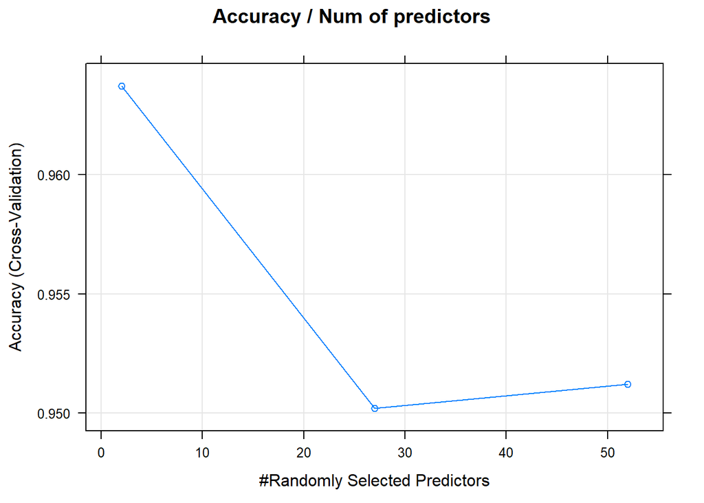

```r
plot(model_rf, main="Accuracy / Num of predictors")
```

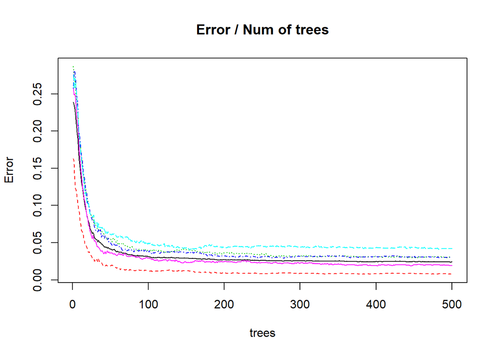

```r
plot(model_rf$finalModel, main="Error / Num of trees")
```

#### Important Features

```r
imp_vars_rf <- varImp(model_rf)
print(imp_vars_rf)
```

```
## rf variable importance
##
##   only 20 most important variables shown (out of 26)
##
##      Overall
## PC15  100.00
## PC7    98.86
## PC3    93.36
## PC1    88.55
## PC4    87.64
## PC13   78.99
## PC5    78.14
## PC12   76.35
## PC17   75.91
## PC2    73.14
## PC9    73.08
## PC16   69.41
## PC8    68.21
## PC18   64.35
## PC6    61.28
## PC10   57.36
## PC26   53.58
## PC14   51.86
## PC20   49.99
## PC23   43.05
```

### Gradient Boosting

Train the model with a cross validation of 3 folds.

```r
control_gbm <- trainControl(method="cv",
                           number=3,
                           verboseIter=FALSE,
                           allowParallel = TRUE)
set.seed(1004)

model_gbm <- train(classe~.,
                   data=train_model,
                   method="gbm",
                   preProcess="pca",
                   trControl = control_gbm)
```

```r
print(model_gbm)
```

```
## Stochastic Gradient Boosting
##
## 14718 samples
##    52 predictor
##     5 classes: 'A', 'B', 'C', 'D', 'E'
##
## Pre-processing: principal component signal extraction (52), centered
##  (52), scaled (52)
## Resampling: Cross-Validated (3 fold)
## Summary of sample sizes: 9812, 9812, 9812
## Resampling results across tuning parameters:
##
##   interaction.depth  n.trees  Accuracy   Kappa
##   1                   50      0.5541514  0.4260047
##   1                  100      0.6137383  0.5070988
##   1                  150      0.6454002  0.5489047
##   2                   50      0.6568827  0.5628030
##   2                  100      0.7229923  0.6484548
##   2                  150      0.7585270  0.6938962
##   3                   50      0.7115777  0.6336773
##   3                  100      0.7755130  0.7154554
##   3                  150      0.8125425  0.7624771
##
## Tuning parameter 'shrinkage' was held constant at a value of 0.1
##
## Tuning parameter 'n.minobsinnode' was held constant at a value of 10
## Accuracy was used to select the optimal model using the largest value.
## The final values used for the model were n.trees = 150,
##  interaction.depth = 3, shrinkage = 0.1 and n.minobsinnode = 10.
```

#### Evaluate the model

```r
predict_gbm <- predict(model_gbm, validate_model)
cm_gbm <- confusionMatrix(predict_gbm, validate_model$classe)
print(cm_gbm)
```

```
## Confusion Matrix and Statistics
##
##           Reference
## Prediction    A    B    C    D    E
##          A 1251   90   34   32   18
##          B   24  737   73   14   58
##          C   32   58  698  107   74
##          D   64   28   30  625   51
##          E   24   36   20   26  700
##
## Overall Statistics
##
##                Accuracy : 0.8179
##                  95% CI : (0.8068, 0.8286)
##     No Information Rate : 0.2845
##     P-Value [Acc > NIR] : < 2.2e-16
##
##                   Kappa : 0.7696
##  Mcnemar's Test P-Value : < 2.2e-16
##
## Statistics by Class:
##
##                      Class: A Class: B Class: C Class: D Class: E
## Sensitivity            0.8968   0.7766   0.8164   0.7774   0.7769
## Specificity            0.9504   0.9573   0.9331   0.9578   0.9735
## Pos Pred Value         0.8779   0.8135   0.7203   0.7832   0.8685
## Neg Pred Value         0.9586   0.9470   0.9601   0.9564   0.9510
## Prevalence             0.2845   0.1935   0.1743   0.1639   0.1837
## Detection Rate         0.2551   0.1503   0.1423   0.1274   0.1427
## Detection Prevalence   0.2906   0.1847   0.1976   0.1627   0.1644
## Balanced Accuracy      0.9236   0.8669   0.8747   0.8676   0.8752
```

The **Gradient Boosting** approach yields a result also with **a good accuracy of 81.79%**.

Plotting the model below.

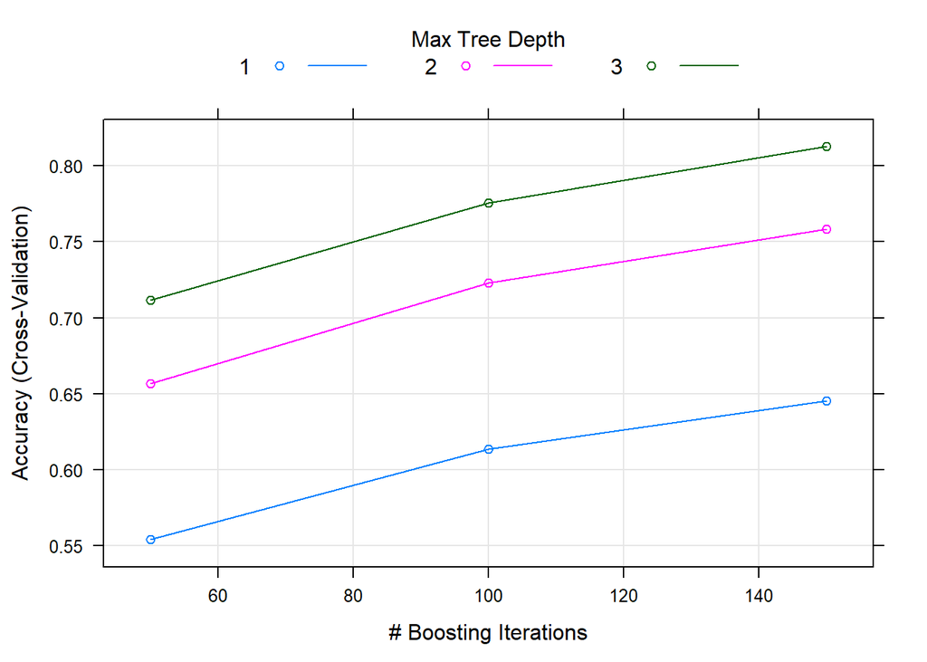

```r
plot(model_gbm)
```

## Conclusion

The **Random Forest** outperforms the others considered in this analysis and provides the greatest accuracy.

We’ll use it to predict the outcome of the testing dataset.

#### Results on the test set

The test set has an additional column, `problem_id` which is not present in the training set. So, we’ll ignore it and predict on rest of the features.

```r
results <- predict(model_rf, newdata=testing[, -53])
print(data.frame(problem_id=testing$problem_id, prediction=results))
```

```
##    problem_id prediction
## 1           1          B
## 2           2          A
## 3           3          C
## 4           4          A
## 5           5          A
## 6           6          B
## 7           7          D
## 8           8          B
## 9           9          A
## 10         10          A
## 11         11          B
## 12         12          C
## 13         13          B
## 14         14          A
## 15         15          E
## 16         16          E
## 17         17          A
## 18         18          B
## 19         19          B
## 20         20          B
```